## Exploratory Data Analysis

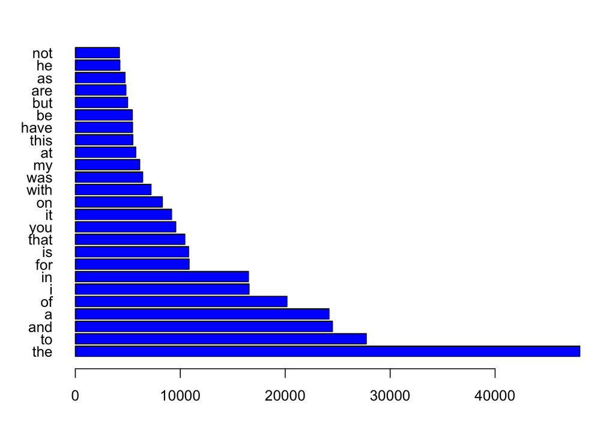

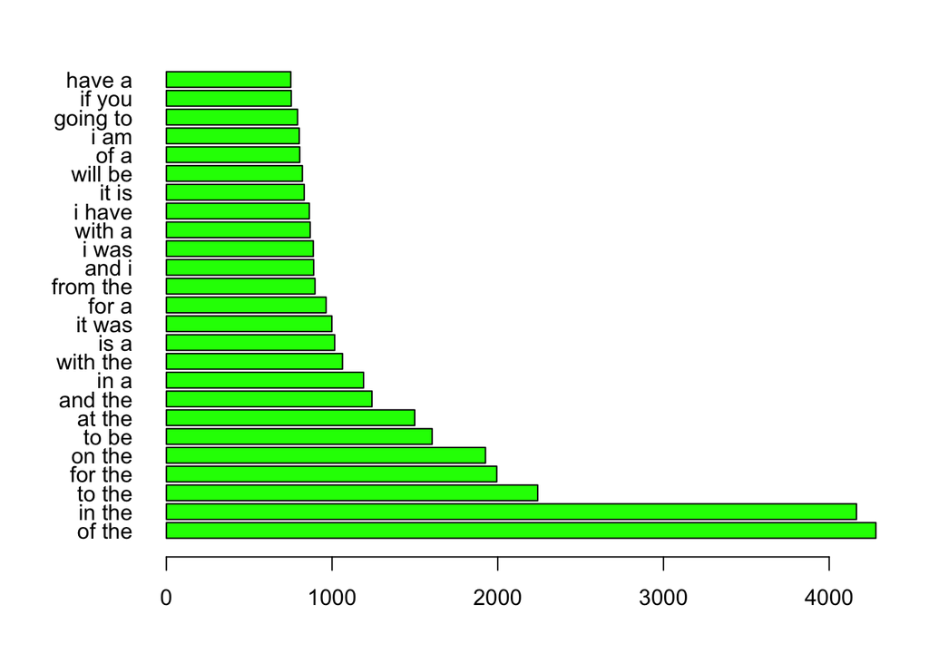

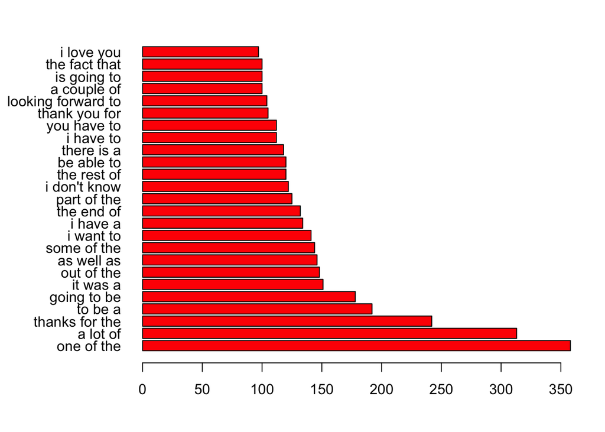

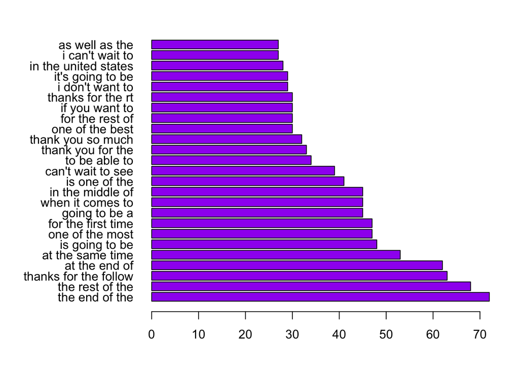

```r
head(unigrams.dfm, 3)
```

```
## Document-feature matrix of: 42,695 documents, 53,046 features.
## (showing first 3 documents and first 6 features)
##        features
## docs    babs i don't know maybe they're
##   text1    1 0     0    0     0       0
##   text2    0 3     1    1     1       1
##   text3    0 0     0    0     3       0
```

```r
head(bigrams.dfm, 3)
```

```
## Document-feature matrix of: 42,695 documents, 444,694 features.
## (showing first 3 documents and first 6 features)
##        features
## docs    i don't don't know know maybe maybe they're they're getting
##   text1       0          0          0             0               0
##   text2       1          1          1             1               1
##   text3       0          0          0             0               0
##        features
## docs    getting too
##   text1           0
##   text2           1
##   text3           0
```

```r
head(trigrams.dfm, 3)
```

```
## Document-feature matrix of: 42,695 documents, 779,437 features.
## (showing first 3 documents and first 6 features)
##        features
## docs    i don't know don't know maybe know maybe they're
##   text1            0                0                  0
##   text2            1                1                  1
##   text3            0                0                  0
##        features
## docs    maybe they're getting they're getting too getting too much
##   text1                     0                   0                0
##   text2                     1                   1                1
##   text3                     0                   0                0
```

```r
head(quadgrams.dfm, 3)
```

```
## Document-feature matrix of: 42,695 documents, 858,242 features.
## (showing first 3 documents and first 6 features)
##        features
## docs    i don't know maybe don't know maybe they're
##   text1                  0                        0
##   text2                  1                        1
##   text3                  0                        0
##        features
## docs    know maybe they're getting maybe they're getting too
##   text1                          0                         0
##   text2                          1                         1
##   text3                          0                         0
##        features
## docs    they're getting too much getting too much sun
##   text1                        0                    0
##   text2                        1                    1
##   text3                        0                    0
```

```r
#
unigrams.freq0 <- colSums(unigrams.dfm)
unigrams.freq <- sort(unigrams.freq0, decreasing=TRUE)
#
bigrams.freq0 <- colSums(bigrams.dfm)
bigrams.freq <- sort(bigrams.freq0, decreasing=TRUE)
#
trigrams.freq0 <- colSums(trigrams.dfm)
trigrams.freq <- sort(trigrams.freq0, decreasing=TRUE)
#
quadgrams.freq0 <- colSums(quadgrams.dfm)
quadgrams.freq <- sort(quadgrams.freq0, decreasing=TRUE)
#
#-------------------------------------------------------------------------
frequency <- 2
#
unigrams.most <- as.numeric()
for (i in 1:length(unigrams.freq)) {
  if (unigrams.freq[i] > frequency) {
    unigrams.most  <- c(unigrams.most, unigrams.freq[i]) }
}
length(unigrams.most)
```

```
## [1] 18939
```

```r
#
bigrams.most <- as.numeric()
for (i in 1:length(bigrams.freq)) {
  if (bigrams.freq[i] > frequency) {
    bigrams.most  <- c(bigrams.most, bigrams.freq[i]) }
}
length(bigrams.most)
```

```
## [1] 48198
```

```r
#
trigrams.most <- as.numeric()
for (i in 1:length(trigrams.freq)) {
  if (trigrams.freq[i] > frequency) {
    trigrams.most  <- c(trigrams.most, trigrams.freq[i]) }
}
length(trigrams.most)
```

```
## [1] 22736
```

```r
#
quadgrams.most <- as.numeric()
for (i in 1:length(quadgrams.freq)) {
  if (quadgrams.freq[i] > frequency) {
    quadgrams.most  <- c(quadgrams.most, quadgrams.freq[i]) }
}
length(quadgrams.most)
```

```
## [1] 4335
```

We then create data frames and select the 25 most frequent occurances in sorted lists of unigrams, bigrams, trigrams and quadgrams and label the columns:

```r
unigrams_most <- data.frame(unigrams.most)
unigrams_most[, 1] <- as.character(names(unigrams.most))
unigrams_most[, 2] <- as.numeric(unigrams.most)
unigrams_most0 <- unigrams_most[1:25,]
colnames(unigrams_most0) <- c("Word","Frequency")
row.names(unigrams_most0) <- NULL
head(unigrams_most0)
```

```
##   Word Frequency
## 1  the     48076
## 2   to     27730
## 3  and     24498
## 4    a     24176
## 5   of     20171
## 6    i     16560
```

```r
#
bigrams_most <- data.frame(bigrams.most)
bigrams_most[, 1] <- as.character(names(bigrams.most))
bigrams_most[, 2] <- as.numeric(bigrams.most)
bigrams_most0 <- bigrams_most[1:25,]
colnames(bigrams_most0) <- c("Word","Frequency")
row.names(bigrams_most0) <- NULL
head(bigrams_most0)
```

```
##      Word Frequency
## 1  of the      4282
## 2  in the      4165
## 3  to the      2241
## 4 for the      1994
## 5  on the      1926
## 6   to be      1604
```

```r
#
trigrams_most <- data.frame(trigrams.most)
trigrams_most[, 1] <- as.character(names(trigrams.most))
trigrams_most[, 2] <- as.numeric(trigrams.most)
trigrams_most0 <- trigrams_most[1:25,]
colnames(trigrams_most0) <- c("Word","Frequency")
row.names(trigrams_most0) <- NULL
head(trigrams_most0)
```

```
##             Word Frequency
## 1     one of the       358
## 2       a lot of       313
## 3 thanks for the       242
## 4        to be a       192
## 5    going to be       178
## 6       it was a       151
```

```r
#
quadgrams_most <- data.frame(quadgrams.most)
quadgrams_most[, 1] <- as.character(names(quadgrams.most))
quadgrams_most[, 2] <- as.numeric(quadgrams.most)
quadgrams_most0 <- quadgrams_most[1:25,]
colnames(quadgrams_most0) <- c("Word","Frequency")
row.names(quadgrams_most0) <- NULL
head(quadgrams_most0)
```

```
##                    Word Frequency
## 1        the end of the        72
## 2       the rest of the        68
## 3 thanks for the follow        63
## 4         at the end of        62
## 5      at the same time        53
## 6        is going to be        48
```

We have created histograms of the unigram, bigram, trigram, and quadgram occurrances from the selected text corpus:

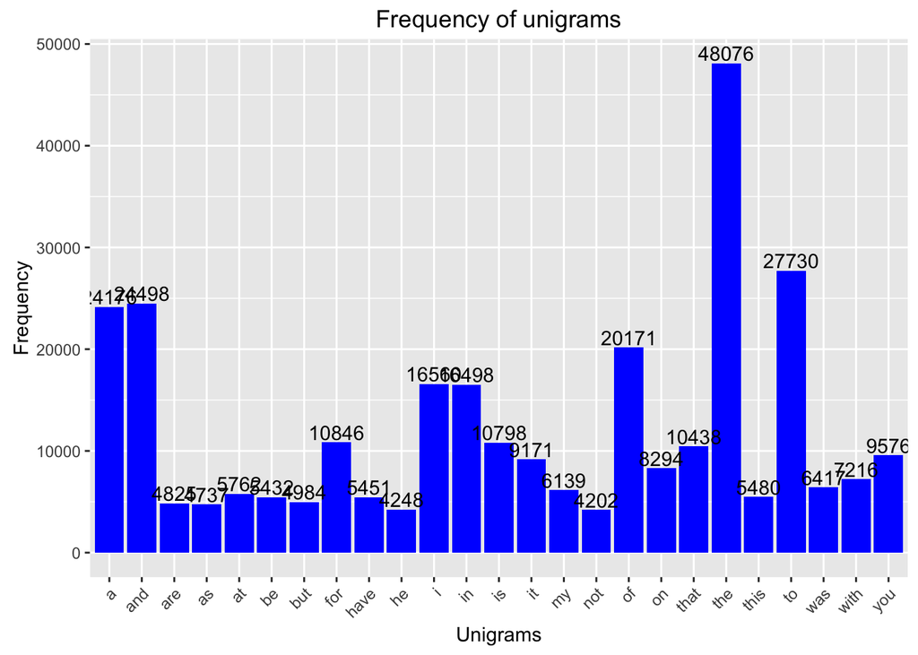

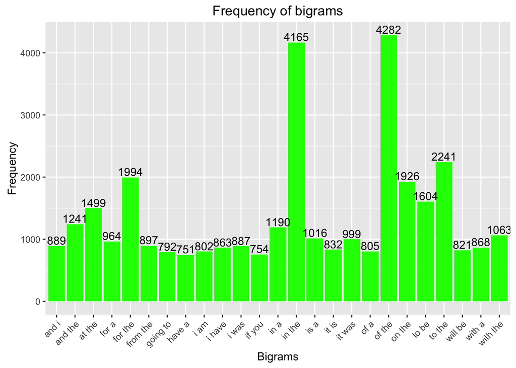

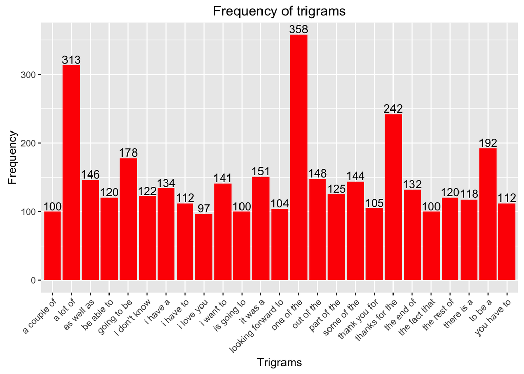

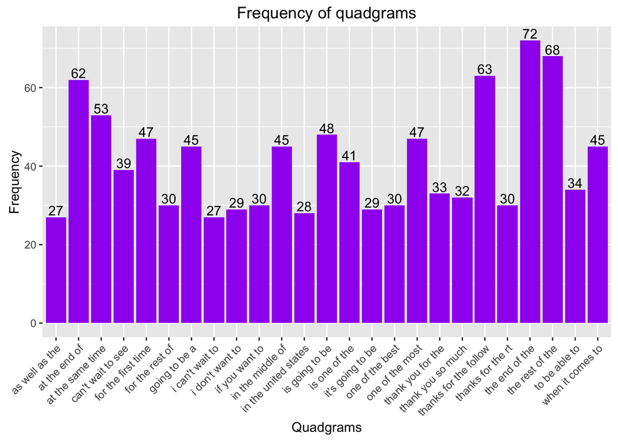

As further illustration, here is a so-called ‘word cloud’ plot for the ‘quadgram’ statistics:

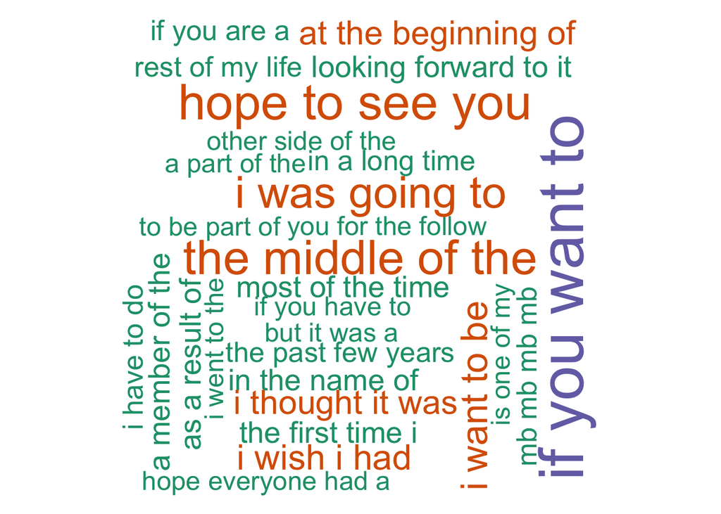

Finally, this is a snapshot of the final interactive ‘shiny app’ application - a word prediction application that uses the ‘Kneser-Ney smoothing’ formalism with calculated continuation probabilities from the individual ngram occurrences in the selected text corpus and estimating probabilities for rare ngrams that did not appear in the corpus. The app provides up to the three most likely word suggestions to continue a typed sentence that is submitted by the user.

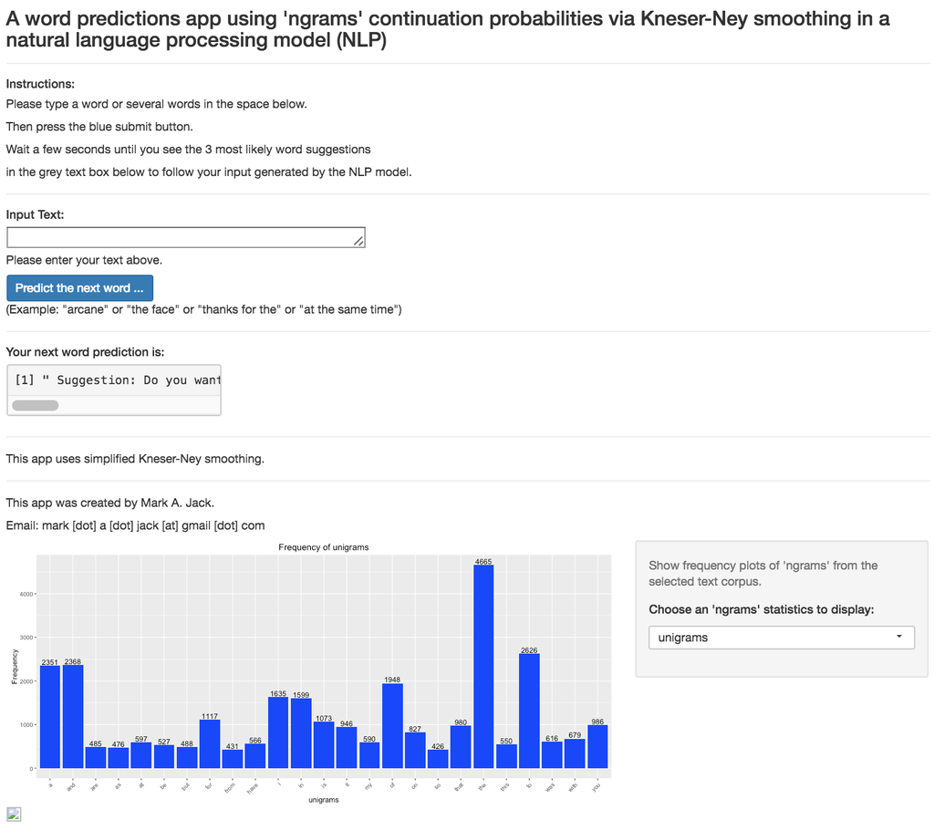